# Models: heatwaves, ozone and their interaction

- Show All Code
- Hide All Code
- View Source

Deliverable 3, preliminary · Heatwaves, ozone and mortality in Santiago, 2009-2020

Author

Amaru Agüero Jiménez

Published

November 23, 2026

**Preliminary**

These results use working definitions that the principal investigator has not confirmed: heatwave hw_p95_2d, high ozone o3_idw_gt_p75 (the delivered 24-hour mean, whose limits are shown on the ozone validation page). They show that the pipeline runs from the death records to the interaction measures and how much the answer depends on the definitions. They are not findings to cite.

## 1 Models

For each death the day of death is compared with the control days of the same municipality, year, month and day of the week, by conditional logistic regression, at single-day lags 0 to 3:

| Model | Linear predictor | Reads as |
| --- | --- | --- |
| Heatwave alone | β₁ HW | Odds ratio of death on a heatwave day |
| Ozone alone | β₂ O3high | Odds ratio of death on a high-ozone day |
| Joint | β₁ HW + β₂ O3high | Each exposure adjusted for the other |
| Compound categories | β₁₀ E10 + β₀₁ E01 + β₁₁ E11 | Heatwave only, high ozone only and both, against neither |

Additive interaction comes from the compound model: REOI = OR₁₁ − OR₁₀ − OR₀₁ + 1, AP = REOI / OR₁₁ and S = (OR₁₁ − 1) / [(OR₁₀ − 1) + (OR₀₁ − 1)], with delta-method intervals. The multiplicative ratio OR₁₁ / (OR₁₀ × OR₀₁) is reported next to them.

**Code/30_models_main.R**

```r
# 30_models_main.R
# Conditional logistic regression of the case-crossover dataset: single
# exposures, joint model, four-category compound exposure and additive
# interaction (REOI, AP, S).
#
# Inputs
#   Data/Derived/case_crossover.csv    (script 21)
#   Data/Derived/exposure_lagged.csv   (script 21)
# Outputs
#   Output/Tables/models_main_or.csv             odds ratios, headline definition
#   Output/Tables/models_main_interaction.csv    REOI, AP, S, headline definition
#   Output/Tables/models_grid.csv                compound model over the definition grid
#   Output/Tables/models_ozone_continuous.csv    ozone per 10 ppb
#
# Models, for each outcome, subgroup and single-day lag (0 to 3):
#   heatwave   logit P = b1 HW
#   ozone      logit P = b2 O3high
#   joint      logit P = b1 HW + b2 O3high
#   compound   logit P = b10 E10 + b01 E01 + b11 E11        (reference E00)
# The compound model is the joint model with its interaction term written as
# categories: OR11 / (OR10 x OR01) is the multiplicative interaction.
#
# The fits use one row per municipality, day of death and referent day,
# weighted by the number of deaths; tests/test_methods.R shows this equals the
# fit on the individual records.

suppressPackageStartupMessages(library(survival))
source(here::here("Code", "00_setup.R"))
source(here::here("Code", "01_functions.R"))

conf_level <- get_param("models", "conf_level")
lags <- unlist(get_param("design", "lags_days"))
heatwave_main <- get_param("models", "heatwave_main")
ozone_main <- paste0(get_param("air_pollution", "ozone_series_main"), "_",
                     get_param("air_pollution", "interpolation_method_main"))
ozone_flag_main <- paste0(ozone_main, "_gt_p", get_param("models", "ozone_cutoff_main"))
outcomes <- names(get_param("mortality", "cause_groups"))
age_labels <- unlist(get_param("mortality", "age_labels"))

cc <- fread(derived_path("case_crossover.csv"), encoding = "UTF-8")
cc[, `:=`(date = as.Date(date), case_date = as.Date(case_date))]
lagged <- fread(derived_path("exposure_lagged.csv"), encoding = "UTF-8")
lagged[, date := as.Date(date)]
stopifnot(all(c(paste0(heatwave_main, "_lag", lags), paste0(ozone_flag_main, "_lag", lags))
              %in% names(lagged)))

# Rows of the case-crossover dataset for an outcome and a subgroup
select_rows <- function(outcome, subgroup) {
  rows <- cc[[outcome]] == TRUE
  if (subgroup %in% age_labels) rows <- rows & cc$age_group == subgroup
  if (subgroup %in% c("male", "female")) rows <- rows & cc$sex == subgroup
  stopifnot(subgroup %in% c("all", age_labels, "male", "female"))
  rows & !is.na(rows)
}

# Collapsed dataset with the position of each row in the lagged exposures
prepare <- function(outcome, subgroup) {
  collapsed <- collapse_case_crossover(cc[select_rows(outcome, subgroup)])
  collapsed[, exposure_row := lagged[collapsed, on = .(com, date), which = TRUE]]
  stopifnot(!anyNA(collapsed$exposure_row))
  collapsed
}

# Attach one heatwave definition and one ozone flag at a lag; keep the strata
# where both are known on every referent day
with_exposure <- function(collapsed, heatwave, ozone_flag, lag) {
  d <- copy(collapsed)
  d[, hw := lagged[[paste0(heatwave, "_lag", lag)]][exposure_row]]
  d[, oz := lagged[[paste0(ozone_flag, "_lag", lag)]][exposure_row]]
  complete <- d[, .(ok = !anyNA(hw) && !anyNA(oz)), by = stratum][ok == TRUE, stratum]
  d <- d[stratum %in% complete]
  d[, `:=`(e10 = as.integer(hw == 1 & oz == 0), e01 = as.integer(hw == 0 & oz == 1),
           e11 = as.integer(hw == 1 & oz == 1))]
  d
}

# Deaths by exposure category on the day of death (lagged as requested)
category_deaths <- function(d) {
  d[case == 1, .(deaths = sum(n_deaths), deaths_e00 = sum(n_deaths[hw == 0 & oz == 0]),
                 deaths_e10 = sum(n_deaths[e10 == 1]), deaths_e01 = sum(n_deaths[e01 == 1]),
                 deaths_e11 = sum(n_deaths[e11 == 1]))]
}

compound_results <- function(d) {
  fit <- fit_conditional_logit(d, c("e10", "e01", "e11"))
  or <- odds_ratios(fit, conf_level)
  interaction <- additive_interaction(coef(fit), vcov(fit), conf_level)
  # Multiplicative interaction: OR11 / (OR10 x OR01), on the log scale
  g <- c(-1, -1, 1)
  log_ratio <- sum(g * coef(fit))
  se_ratio <- sqrt(drop(t(g) %*% vcov(fit) %*% g))
  z <- stats::qnorm(1 - (1 - conf_level) / 2)
  interaction <- rbind(interaction, data.table(
    measure = "multiplicative ratio", estimate = exp(log_ratio),
    low = exp(log_ratio - z * se_ratio), high = exp(log_ratio + z * se_ratio), null_value = 1
  ))
  list(or = or, interaction = interaction)
}

# ---- 1. Headline definition: all outcomes, subgroups and lags ----------------

subgroups <- c("all", age_labels, "male", "female")
main_jobs <- CJ(outcome = outcomes, subgroup = subgroups, sorted = FALSE)

run_main <- function(i) {
  outcome <- main_jobs$outcome[i]
  subgroup <- main_jobs$subgroup[i]
  collapsed <- prepare(outcome, subgroup)
  or_list <- list()
  interaction_list <- list()
  for (lag in lags) {
    d <- with_exposure(collapsed, heatwave_main, ozone_flag_main, lag)
    counts <- category_deaths(d)
    label <- data.table(outcome = outcome, subgroup = subgroup, lag = lag)
    # A category with no deaths on the day of death has no estimable odds ratio
    estimable <- all(unlist(counts[, .(deaths_e10, deaths_e01, deaths_e11)]) > 0)
    logged <- with_warnings(list(
      single = rbind(
        cbind(model = "heatwave", odds_ratios(fit_conditional_logit(d, "hw"), conf_level)),
        cbind(model = "ozone", odds_ratios(fit_conditional_logit(d, "oz"), conf_level)),
        cbind(model = "joint", odds_ratios(fit_conditional_logit(d, c("hw", "oz")), conf_level))
      ),
      compound = if (estimable) compound_results(d)
    ))
    fit_warnings <- paste(unique(logged$warnings), collapse = " | ")
    or_rows <- logged$value$single
    if (estimable) {
      or_rows <- rbind(or_rows, cbind(model = "compound", logged$value$compound$or))
      interaction_list[[length(interaction_list) + 1]] <- cbind(
        label, logged$value$compound$interaction, counts, fit_warnings = fit_warnings
      )
    }
    or_list[[length(or_list) + 1]] <- cbind(label, or_rows, counts, fit_warnings = fit_warnings)
  }
  list(or = rbindlist(or_list), interaction = rbindlist(interaction_list))
}
# The result does not depend on the number of cores.
main_results <- parallel::mclapply(seq_len(nrow(main_jobs)), run_main,
                                   mc.cores = parallel::detectCores())
failed <- vapply(main_results, inherits, logical(1), what = "try-error")
if (any(failed)) stop("Model run failed: ", main_results[[which(failed)[1]]], call. = FALSE)
main_or <- rbindlist(lapply(main_results, `[[`, "or"))
main_interaction <- rbindlist(lapply(main_results, `[[`, "interaction"))
main_or[, `:=`(heatwave = heatwave_main, ozone = ozone_flag_main)]
main_interaction[, `:=`(heatwave = heatwave_main, ozone = ozone_flag_main)]
fwrite(main_or, file.path(dir_tables, "models_main_or.csv"))
fwrite(main_interaction, file.path(dir_tables, "models_main_interaction.csv"))

# ---- 2. Definition grid: compound model, two outcomes, all lags --------------

heatwaves <- unique(sub("_lag[0-9]+$", "", grep("^hw_", names(lagged), value = TRUE)))
ozone_flags <- unique(sub("_lag[0-9]+$", "", grep("_gt_p[0-9]+_lag", names(lagged), value = TRUE)))
grid_outcomes <- c("non_accidental", "cardiopulmonary")
grid_jobs <- CJ(outcome = grid_outcomes, heatwave = heatwaves, ozone = ozone_flags, sorted = FALSE)
grid_data <- lapply(setNames(grid_outcomes, grid_outcomes), prepare, subgroup = "all")

run_grid <- function(i) {
  job <- grid_jobs[i]
  rbindlist(lapply(lags, function(lag) {
    d <- with_exposure(grid_data[[job$outcome]], job$heatwave, job$ozone, lag)
    counts <- category_deaths(d)
    # A category with no deaths on the day of death has no estimable odds ratio
    if (any(unlist(counts[, .(deaths_e10, deaths_e01, deaths_e11)]) == 0)) {
      return(cbind(job, lag = lag, counts, estimable = FALSE))
    }
    logged <- with_warnings(compound_results(d))
    compound <- logged$value
    or <- dcast(compound$or[, .(term, or, or_low, or_high)], . ~ term,
                value.var = c("or", "or_low", "or_high"))[, !"."]
    measures <- dcast(compound$interaction[, .(measure = gsub(" ", "_", tolower(measure)),
                                               estimate, low, high)],
                      . ~ measure, value.var = c("estimate", "low", "high"))[, !"."]
    cbind(job, lag = lag, counts, estimable = TRUE, or, measures,
          fit_warnings = paste(unique(logged$warnings), collapse = " | "))
  }), fill = TRUE)
}
grid_results <- parallel::mclapply(seq_len(nrow(grid_jobs)), run_grid,
                                   mc.cores = parallel::detectCores())
failed <- vapply(grid_results, inherits, logical(1), what = "try-error")
if (any(failed)) stop("Grid run failed: ", grid_results[[which(failed)[1]]], call. = FALSE)
fwrite(rbindlist(grid_results, fill = TRUE), file.path(dir_tables, "models_grid.csv"))

# ---- 3. Ozone as a continuous exposure, per 10 ppb ---------------------------

ozone_series <- as.vector(outer(c("o3", "o3obs", "o3mda8"), c("idw", "ok"), paste, sep = "_"))
continuous <- rbindlist(lapply(grid_outcomes, function(outcome) {
  collapsed <- grid_data[[outcome]]
  rbindlist(lapply(ozone_series, function(series) rbindlist(lapply(lags, function(lag) {
    d <- copy(collapsed)
    d[, ozone_10ppb := lagged[[paste0(series, "_lag", lag)]][exposure_row] / 10]
    d[, hw := lagged[[paste0(heatwave_main, "_lag", lag)]][exposure_row]]
    complete <- d[, .(ok = !anyNA(ozone_10ppb) && !anyNA(hw)), by = stratum][ok == TRUE, stratum]
    d <- d[stratum %in% complete]
    rbind(
      cbind(outcome = outcome, series = series, lag = lag, adjustment = "none",
            odds_ratios(fit_conditional_logit(d, "ozone_10ppb"), conf_level)),
      cbind(outcome = outcome, series = series, lag = lag, adjustment = heatwave_main,
            odds_ratios(fit_conditional_logit(d, c("ozone_10ppb", "hw")), conf_level))
    )[term == "ozone_10ppb"]
  }))))
}))
fwrite(continuous, file.path(dir_tables, "models_ozone_continuous.csv"))

message("Models written: ", nrow(main_or), " odds ratios (headline), ",
        nrow(grid_jobs) * length(lags), " grid fits")
```

```r
n_warn_main <- main_or[!is.na(fit_warnings) & fit_warnings != "", .N]
n_warn_grid <- grid[!is.na(fit_warnings) & fit_warnings != "", .N]
not_estimable <- grid[estimable == FALSE, .N]
```

Fits with a warning from the optimiser: 0 rows of the headline tables and 10 cells of the definition grid. Grid cells without deaths in one exposure category, where no odds ratio exists: 28.

## 2 Non-accidental mortality, working definitions

```r
headline <- main_or[outcome == "non_accidental" & subgroup == "all"]
headline[, `:=`(Model = model_labels[model], Term = term_labels[term],
                value = ci(or, or_low, or_high, 3))]
kable(dcast(headline, factor(Model, levels = model_labels) + factor(Term, levels = term_labels) ~ lag,
            value.var = "value"),
      col.names = c("Model", "Term", "Lag 0", "Lag 1", "Lag 2", "Lag 3"))
```

Table 1: Odds ratios (95% confidence interval) for non-accidental mortality by lag.

| Model | Term | Lag 0 | Lag 1 | Lag 2 | Lag 3 |
| --- | --- | --- | --- | --- | --- |
| Heatwave alone | Heatwave | 1.075 (1.051 to 1.100) | 1.063 (1.040 to 1.088) | 1.034 (1.011 to 1.058) | 1.022 (0.999 to 1.046) |
| Ozone alone | High ozone | 1.041 (1.025 to 1.057) | 1.033 (1.017 to 1.049) | 1.010 (0.995 to 1.026) | 1.001 (0.986 to 1.016) |
| Joint | Heatwave | 1.064 (1.040 to 1.089) | 1.055 (1.030 to 1.080) | 1.032 (1.009 to 1.057) | 1.023 (0.999 to 1.047) |
| Joint | High ozone | 1.031 (1.015 to 1.047) | 1.025 (1.009 to 1.041) | 1.006 (0.990 to 1.021) | 0.998 (0.982 to 1.013) |
| Compound categories | Heatwave only (E10) | 1.067 (1.032 to 1.104) | 1.051 (1.016 to 1.087) | 1.021 (0.987 to 1.057) | 1.007 (0.973 to 1.042) |
| Compound categories | High ozone only (E01) | 1.032 (1.015 to 1.049) | 1.024 (1.007 to 1.041) | 1.003 (0.987 to 1.020) | 0.994 (0.978 to 1.011) |
| Compound categories | Heatwave and high ozone (E11) | 1.096 (1.064 to 1.128) | 1.083 (1.052 to 1.116) | 1.046 (1.015 to 1.077) | 1.031 (1.001 to 1.062) |

```r
counts <- unique(headline[, .(lag, deaths, deaths_e00, deaths_e10, deaths_e01, deaths_e11)])
kable(counts, format.args = list(big.mark = ","),
      col.names = c("Lag", "Deaths", "Neither (E00)", "Heatwave only (E10)",
                    "High ozone only (E01)", "Both (E11)"))
```

Table 2: Deaths by exposure category on the lagged day, non-accidental mortality.

| Lag | Deaths | Neither (E00) | Heatwave only (E10) | High ozone only (E01) | Both (E11) |
| --- | --- | --- | --- | --- | --- |
| 0 | 135,359 | 95,499 | 4,919 | 27,597 | 7,344 |
| 1 | 135,359 | 95,667 | 4,830 | 27,558 | 7,304 |
| 2 | 135,359 | 96,098 | 4,713 | 27,378 | 7,170 |
| 3 | 135,359 | 96,201 | 4,699 | 27,376 | 7,083 |

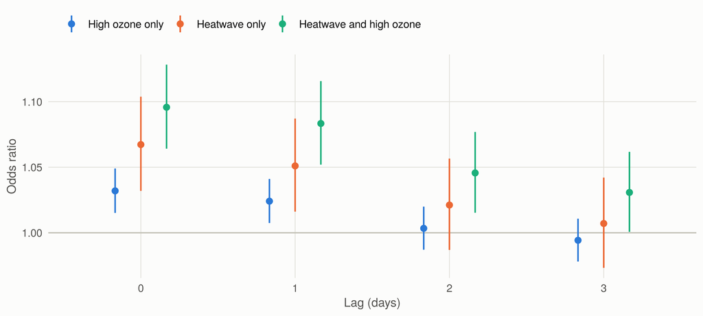

Figure 1: Odds ratios of non-accidental death by exposure category and lag, compound model. Bars are 95% confidence intervals.

```r
compound <- headline[model == "compound"]
compound[, category := factor(c(e10 = "Heatwave only", e01 = "High ozone only",
                                e11 = "Heatwave and high ozone")[term],
                              levels = c("High ozone only", "Heatwave only", "Heatwave and high ozone"))]
ggplot(compound, aes(factor(lag), or, colour = category)) +
  geom_hline(yintercept = 1, colour = ink$axis) +
  geom_pointrange(aes(ymin = or_low, ymax = or_high), position = position_dodge(width = 0.5),
                  linewidth = 0.6, size = 0.35) +
  scale_colour_manual(values = colour_compound[levels(compound$category)]) +
  labs(x = "Lag (days)", y = "Odds ratio", colour = NULL)
```

```r
h0 <- headline[lag == 0 & model == "compound"]
r_main <- main_int[outcome == "non_accidental" & subgroup == "all" & measure == "REOI"]
```

With the working definitions, on the day of exposure the odds of non-accidental death are 1.07 (1.03 to 1.10) times higher on heatwave-only days, 1.03 (1.02 to 1.05) on high-ozone-only days and 1.10 (1.06 to 1.13) on days with both, each against days with neither. The associations weaken with the lag. The joint odds ratio is close to what the two single excesses add up to: the REOI interval includes zero at every lag (lag 0: -0.004 (-0.052 to 0.045); lag 1: 0.008 (-0.040 to 0.056); lag 2: 0.021 (-0.026 to 0.068); lag 3: 0.029 (-0.017 to 0.076)).

### 2.1 Additive interaction

```r
interaction <- main_int[outcome %in% c("non_accidental", "cardiopulmonary") & subgroup == "all"]
interaction[, value := ci_measure(measure, estimate, low, high)]
interaction[, Outcome := cause_labels[outcome]]
kable(dcast(interaction, factor(Outcome, levels = cause_labels[1:2]) +
              factor(measure, levels = c("REOI", "AP", "S", "multiplicative ratio")) ~ lag,
            value.var = "value"),
      col.names = c("Outcome", "Measure", "Lag 0", "Lag 1", "Lag 2", "Lag 3"))
```

Table 3: Interaction between heatwave and high ozone, non-accidental and cardiopulmonary mortality. REOI and AP have null value 0; S and the multiplicative ratio have null value 1.

| Outcome | Measure | Lag 0 | Lag 1 | Lag 2 | Lag 3 |
| --- | --- | --- | --- | --- | --- |
| Non-accidental | REOI | -0.004 (-0.052 to 0.045) | 0.008 (-0.040 to 0.056) | 0.021 (-0.026 to 0.068) | 0.029 (-0.017 to 0.076) |
| Non-accidental | AP | -0.003 (-0.047 to 0.041) | 0.008 (-0.037 to 0.052) | 0.020 (-0.024 to 0.065) | 0.029 (-0.016 to 0.073) |
| Non-accidental | S | 0.965 (0.589 to 1.581) | 1.110 (0.599 to 2.057) | 1.860 (0.351 to 9.862) | 22.899 (interval not informative) |
| Non-accidental | multiplicative ratio | 0.995 (0.951 to 1.041) | 1.007 (0.962 to 1.053) | 1.021 (0.975 to 1.068) | 1.029 (0.983 to 1.078) |
| Cardiopulmonary | REOI | -0.031 (-0.108 to 0.047) | -0.016 (-0.094 to 0.062) | 0.024 (-0.051 to 0.099) | 0.043 (-0.032 to 0.117) |
| Cardiopulmonary | AP | -0.029 (-0.103 to 0.045) | -0.015 (-0.088 to 0.058) | 0.023 (-0.049 to 0.095) | 0.042 (-0.030 to 0.113) |
| Cardiopulmonary | S | 0.646 (0.218 to 1.920) | 0.832 (0.346 to 1.999) | 3.264 (interval not informative) | -2.591 (interval not informative) |
| Cardiopulmonary | multiplicative ratio | 0.971 (0.902 to 1.044) | 0.985 (0.916 to 1.059) | 1.024 (0.951 to 1.102) | 1.043 (0.969 to 1.123) |

## 3 By cause of death

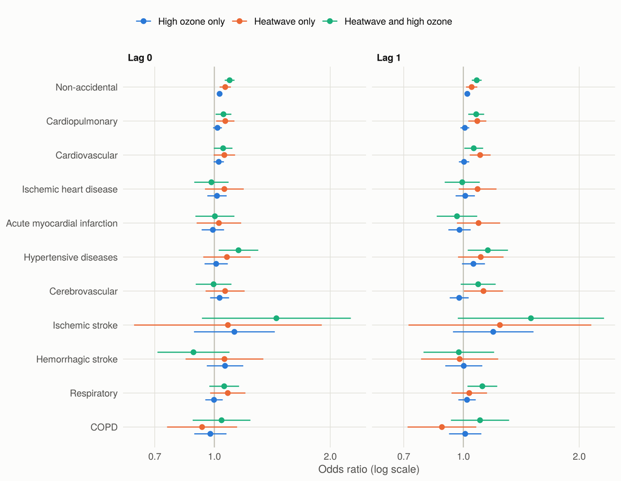

Figure 2: Odds ratios by cause of death and exposure category, lags 0 and 1, compound model. Bars are 95% confidence intervals.

```r
causes <- main_or[subgroup == "all" & model == "compound" & lag %in% 0:1]
causes[, category := factor(c(e10 = "Heatwave only", e01 = "High ozone only",
                              e11 = "Heatwave and high ozone")[term],
                            levels = c("High ozone only", "Heatwave only", "Heatwave and high ozone"))]
causes[, cause := factor(cause_labels[outcome], levels = rev(cause_labels))]
ggplot(causes, aes(or, cause, colour = category)) +
  geom_vline(xintercept = 1, colour = ink$axis) +
  geom_pointrange(aes(xmin = or_low, xmax = or_high), position = position_dodge(width = 0.6),
                  linewidth = 0.5, size = 0.3) +
  facet_wrap(~paste("Lag", lag)) +
  scale_colour_manual(values = colour_compound[levels(causes$category)]) +
  scale_x_log10() +
  labs(x = "Odds ratio (log scale)", y = NULL, colour = NULL)
```

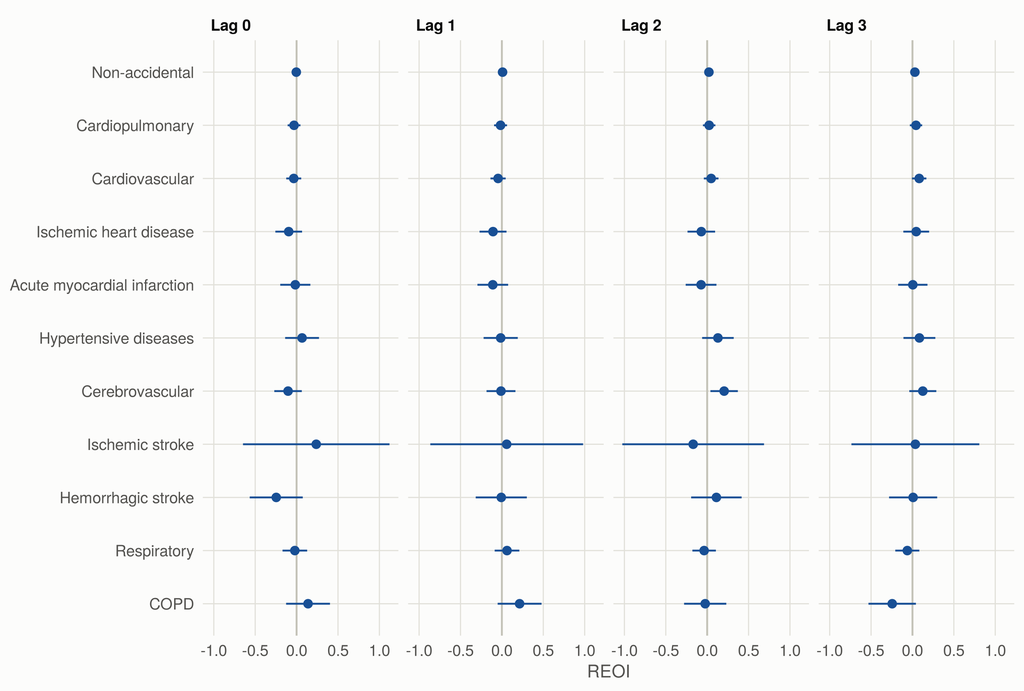

Figure 3: Relative excess odds due to interaction (REOI) by cause of death and lag. Bars are 95% confidence intervals; zero means no additive interaction.

```r
reoi <- main_int[subgroup == "all" & measure == "REOI"]
reoi[, cause := factor(cause_labels[outcome], levels = rev(cause_labels))]
ggplot(reoi, aes(estimate, cause)) +
  geom_vline(xintercept = 0, colour = ink$axis) +
  geom_pointrange(aes(xmin = low, xmax = high), colour = ramp_blue[6], linewidth = 0.5, size = 0.3) +
  facet_wrap(~paste("Lag", lag), nrow = 1) +
  labs(x = "REOI", y = NULL)
```

```r
cause_table <- merge(
  dcast(main_or[subgroup == "all" & model == "compound"], outcome + lag + deaths + deaths_e11 ~ term,
        value.var = c("or", "or_low", "or_high")),
  main_int[subgroup == "all" & measure == "REOI", .(outcome, lag, reoi = estimate, reoi_low = low, reoi_high = high)],
  by = c("outcome", "lag")
)
cause_table <- cause_table[, .(
  Cause = factor(cause_labels[outcome], levels = cause_labels), Lag = lag, Deaths = deaths,
  `Deaths in E11` = deaths_e11,
  `Heatwave only` = ci(or_e10, or_low_e10, or_high_e10),
  `High ozone only` = ci(or_e01, or_low_e01, or_high_e01),
  `Both` = ci(or_e11, or_low_e11, or_high_e11),
  REOI = ci(reoi, reoi_low, reoi_high)
)][order(Cause, Lag)]
kableExtra::scroll_box(
  kableExtra::kable_styling(kable(cause_table, format = "html", format.args = list(big.mark = ",")),
                            bootstrap_options = c("striped", "condensed"), font_size = 12),
  height = "420px"
)
```

Table 4: Compound model by cause of death: deaths, odds ratios and REOI with 95% confidence intervals.

| Cause | Lag | Deaths | Deaths in E11 | Heatwave only | High ozone only | Both | REOI |
| --- | --- | --- | --- | --- | --- | --- | --- |
| Non-accidental | 0 | 135,359 | 7,344 | 1.07 (1.03 to 1.10) | 1.03 (1.02 to 1.05) | 1.10 (1.06 to 1.13) | -0.00 (-0.05 to 0.04) |
| Non-accidental | 1 | 135,359 | 7,304 | 1.05 (1.02 to 1.09) | 1.02 (1.01 to 1.04) | 1.08 (1.05 to 1.12) | 0.01 (-0.04 to 0.06) |
| Non-accidental | 2 | 135,359 | 7,170 | 1.02 (0.99 to 1.06) | 1.00 (0.99 to 1.02) | 1.05 (1.02 to 1.08) | 0.02 (-0.03 to 0.07) |
| Non-accidental | 3 | 135,359 | 7,083 | 1.01 (0.97 to 1.04) | 0.99 (0.98 to 1.01) | 1.03 (1.00 to 1.06) | 0.03 (-0.02 to 0.08) |
| Cardiopulmonary | 0 | 52,012 | 2,807 | 1.07 (1.01 to 1.13) | 1.02 (0.99 to 1.05) | 1.06 (1.01 to 1.11) | -0.03 (-0.11 to 0.05) |
| Cardiopulmonary | 1 | 52,012 | 2,794 | 1.09 (1.03 to 1.15) | 1.01 (0.98 to 1.04) | 1.08 (1.03 to 1.13) | -0.02 (-0.09 to 0.06) |
| Cardiopulmonary | 2 | 52,012 | 2,745 | 1.02 (0.96 to 1.08) | 0.99 (0.97 to 1.02) | 1.03 (0.99 to 1.09) | 0.02 (-0.05 to 0.10) |
| Cardiopulmonary | 3 | 52,012 | 2,725 | 1.00 (0.94 to 1.05) | 0.99 (0.97 to 1.02) | 1.03 (0.98 to 1.08) | 0.04 (-0.03 to 0.12) |
| Cardiovascular | 0 | 38,545 | 1,991 | 1.06 (1.00 to 1.13) | 1.03 (1.00 to 1.06) | 1.05 (1.00 to 1.11) | -0.03 (-0.12 to 0.06) |
| Cardiovascular | 1 | 38,545 | 1,963 | 1.11 (1.04 to 1.18) | 1.00 (0.97 to 1.04) | 1.06 (1.01 to 1.13) | -0.05 (-0.14 to 0.05) |
| Cardiovascular | 2 | 38,545 | 1,983 | 1.02 (0.95 to 1.09) | 0.99 (0.96 to 1.02) | 1.05 (1.00 to 1.11) | 0.05 (-0.04 to 0.14) |
| Cardiovascular | 3 | 38,545 | 1,955 | 0.98 (0.92 to 1.04) | 0.98 (0.95 to 1.02) | 1.05 (0.99 to 1.11) | 0.08 (-0.01 to 0.17) |
| Ischemic heart disease | 0 | 11,179 | 574 | 1.06 (0.95 to 1.19) | 1.02 (0.96 to 1.08) | 0.98 (0.89 to 1.09) | -0.10 (-0.26 to 0.07) |
| Ischemic heart disease | 1 | 11,179 | 557 | 1.09 (0.97 to 1.22) | 1.01 (0.95 to 1.07) | 0.99 (0.89 to 1.10) | -0.11 (-0.27 to 0.06) |
| Ischemic heart disease | 2 | 11,179 | 579 | 1.11 (0.99 to 1.24) | 1.00 (0.94 to 1.06) | 1.04 (0.94 to 1.15) | -0.07 (-0.24 to 0.10) |
| Ischemic heart disease | 3 | 11,179 | 569 | 0.96 (0.85 to 1.08) | 1.01 (0.95 to 1.07) | 1.01 (0.91 to 1.12) | 0.05 (-0.11 to 0.20) |
| Acute myocardial infarction | 0 | 8,403 | 449 | 1.03 (0.90 to 1.17) | 0.99 (0.93 to 1.06) | 1.00 (0.89 to 1.13) | -0.02 (-0.20 to 0.17) |
| Acute myocardial infarction | 1 | 8,403 | 414 | 1.10 (0.96 to 1.25) | 0.98 (0.91 to 1.04) | 0.96 (0.85 to 1.09) | -0.11 (-0.30 to 0.08) |
| Acute myocardial infarction | 2 | 8,403 | 436 | 1.06 (0.93 to 1.21) | 1.02 (0.96 to 1.09) | 1.01 (0.90 to 1.14) | -0.07 (-0.26 to 0.11) |
| Acute myocardial infarction | 3 | 8,403 | 409 | 0.95 (0.83 to 1.09) | 1.02 (0.96 to 1.09) | 0.98 (0.87 to 1.10) | 0.00 (-0.17 to 0.18) |
| Hypertensive diseases | 0 | 7,737 | 451 | 1.08 (0.94 to 1.24) | 1.01 (0.94 to 1.08) | 1.16 (1.03 to 1.30) | 0.07 (-0.14 to 0.27) |
| Hypertensive diseases | 1 | 7,737 | 437 | 1.11 (0.97 to 1.27) | 1.06 (0.99 to 1.14) | 1.16 (1.03 to 1.31) | -0.01 (-0.22 to 0.19) |
| Hypertensive diseases | 2 | 7,737 | 450 | 0.99 (0.86 to 1.14) | 0.96 (0.90 to 1.03) | 1.09 (0.97 to 1.23) | 0.13 (-0.06 to 0.32) |
| Hypertensive diseases | 3 | 7,737 | 429 | 1.00 (0.87 to 1.15) | 1.00 (0.94 to 1.08) | 1.08 (0.96 to 1.22) | 0.08 (-0.11 to 0.28) |
| Cerebrovascular | 0 | 11,421 | 529 | 1.07 (0.95 to 1.20) | 1.03 (0.98 to 1.09) | 1.00 (0.89 to 1.11) | -0.10 (-0.27 to 0.06) |
| Cerebrovascular | 1 | 11,421 | 576 | 1.13 (1.00 to 1.27) | 0.98 (0.92 to 1.03) | 1.09 (0.98 to 1.21) | -0.01 (-0.19 to 0.16) |
| Cerebrovascular | 2 | 11,421 | 591 | 0.97 (0.86 to 1.10) | 0.94 (0.89 to 1.00) | 1.12 (1.01 to 1.24) | 0.20 (0.04 to 0.37) |
| Cerebrovascular | 3 | 11,421 | 567 | 0.98 (0.87 to 1.11) | 0.96 (0.91 to 1.02) | 1.07 (0.96 to 1.18) | 0.12 (-0.04 to 0.29) |
| Ischemic stroke | 0 | 571 | 33 | 1.08 (0.62 to 1.90) | 1.13 (0.89 to 1.44) | 1.45 (0.93 to 2.26) | 0.24 (-0.65 to 1.12) |
| Ischemic stroke | 1 | 571 | 34 | 1.24 (0.72 to 2.15) | 1.20 (0.94 to 1.52) | 1.50 (0.97 to 2.32) | 0.06 (-0.86 to 0.98) |
| Ischemic stroke | 2 | 571 | 26 | 1.33 (0.80 to 2.22) | 0.95 (0.74 to 1.22) | 1.11 (0.68 to 1.81) | -0.17 (-1.03 to 0.69) |
| Ischemic stroke | 3 | 571 | 33 | 1.02 (0.58 to 1.79) | 1.13 (0.89 to 1.45) | 1.19 (0.77 to 1.83) | 0.04 (-0.74 to 0.81) |
| Hemorrhagic stroke | 0 | 3,013 | 127 | 1.06 (0.84 to 1.34) | 1.07 (0.96 to 1.19) | 0.88 (0.71 to 1.09) | -0.25 (-0.57 to 0.07) |
| Hemorrhagic stroke | 1 | 3,013 | 137 | 0.98 (0.78 to 1.23) | 1.00 (0.90 to 1.12) | 0.97 (0.79 to 1.20) | -0.01 (-0.32 to 0.30) |
| Hemorrhagic stroke | 2 | 3,013 | 141 | 0.94 (0.73 to 1.20) | 0.88 (0.79 to 0.99) | 0.93 (0.76 to 1.15) | 0.11 (-0.19 to 0.42) |
| Hemorrhagic stroke | 3 | 3,013 | 130 | 0.89 (0.70 to 1.14) | 0.96 (0.86 to 1.07) | 0.86 (0.70 to 1.06) | 0.01 (-0.28 to 0.30) |
| Respiratory | 0 | 13,467 | 816 | 1.08 (0.98 to 1.20) | 1.00 (0.95 to 1.05) | 1.06 (0.97 to 1.16) | -0.02 (-0.17 to 0.13) |
| Respiratory | 1 | 13,467 | 831 | 1.04 (0.93 to 1.15) | 1.02 (0.97 to 1.08) | 1.12 (1.02 to 1.22) | 0.06 (-0.09 to 0.21) |
| Respiratory | 2 | 13,467 | 762 | 1.02 (0.91 to 1.13) | 1.01 (0.96 to 1.06) | 0.99 (0.90 to 1.08) | -0.04 (-0.18 to 0.11) |
| Respiratory | 3 | 13,467 | 770 | 1.04 (0.94 to 1.16) | 1.02 (0.96 to 1.07) | 1.00 (0.91 to 1.09) | -0.06 (-0.21 to 0.08) |
| COPD | 0 | 3,925 | 208 | 0.93 (0.75 to 1.15) | 0.98 (0.89 to 1.08) | 1.04 (0.88 to 1.24) | 0.14 (-0.13 to 0.40) |
| COPD | 1 | 3,925 | 214 | 0.88 (0.72 to 1.08) | 1.01 (0.92 to 1.11) | 1.11 (0.93 to 1.31) | 0.21 (-0.05 to 0.48) |
| COPD | 2 | 3,925 | 194 | 0.94 (0.76 to 1.15) | 1.00 (0.91 to 1.10) | 0.92 (0.77 to 1.09) | -0.02 (-0.28 to 0.23) |
| COPD | 3 | 3,925 | 187 | 1.14 (0.94 to 1.39) | 1.04 (0.94 to 1.14) | 0.94 (0.78 to 1.12) | -0.24 (-0.53 to 0.04) |

## 4 By age and sex

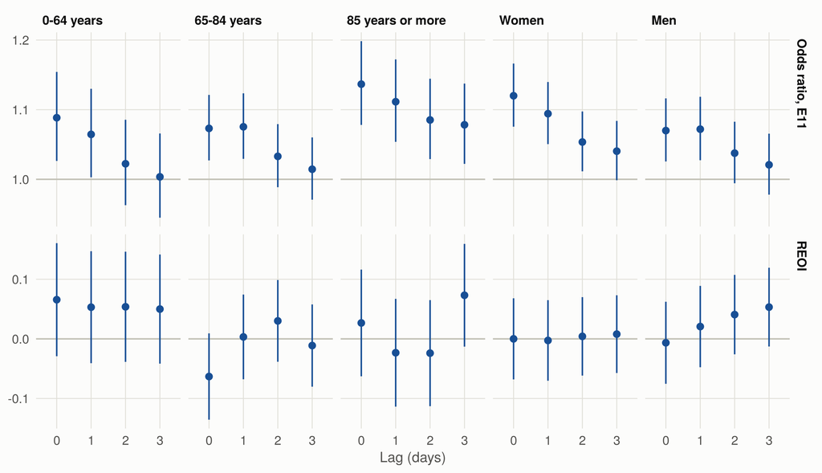

Figure 4: Non-accidental mortality by age group and sex: odds ratio of days with both exposures (E11) and REOI, by lag. Bars are 95% confidence intervals.

```r
sub_or <- main_or[outcome == "non_accidental" & subgroup != "all" & model == "compound" & term == "e11",
                  .(subgroup, lag, measure = "Odds ratio, E11", estimate = or,
                    low = or_low, high = or_high, null = 1)]
sub_reoi <- main_int[outcome == "non_accidental" & subgroup != "all" & measure == "REOI",
                     .(subgroup, lag, measure = "REOI", estimate, low, high, null = 0)]
subgroups <- rbind(sub_or, sub_reoi)
subgroups[, subgroup := factor(subgroup, levels = c("0-64", "65-84", "85+", "female", "male"),
                               labels = c("0-64 years", "65-84 years", "85 years or more", "Women", "Men"))]
ggplot(subgroups, aes(factor(lag), estimate)) +
  geom_hline(aes(yintercept = null), colour = ink$axis) +
  geom_pointrange(aes(ymin = low, ymax = high), colour = ramp_blue[6], linewidth = 0.5, size = 0.3) +
  facet_grid(measure ~ subgroup, scales = "free_y") +
  labs(x = "Lag (days)", y = NULL)
```

```r
e11 <- main_or[outcome == "non_accidental" & model == "compound" & term == "e11" & subgroup != "all",
               .(subgroup, lag, log_or, se)]
pairs <- list(c("0-64", "65-84"), c("0-64", "85+"), c("female", "male"))
tests <- rbindlist(lapply(pairs, function(pair) {
  d <- merge(e11[subgroup == pair[1]], e11[subgroup == pair[2]], by = "lag", suffixes = c("_a", "_b"))
  d[, .(comparison = paste(pair[2], "against", pair[1]), lag,
        ratio_of_odds_ratios = exp(log_or_b - log_or_a),
        z = (log_or_b - log_or_a) / sqrt(se_a^2 + se_b^2))][
    , p_value := 2 * pnorm(-abs(z))]
}))
kable(tests, digits = c(0, 0, 3, 2, 3),
      col.names = c("Comparison", "Lag", "Ratio of odds ratios", "z", "p"))
```

Table 5: Difference between subgroups in the log odds ratio of the compound exposure (E11): two-sample z-test against the first subgroup of each pair.

| Comparison | Lag | Ratio of odds ratios | z | p |
| --- | --- | --- | --- | --- |
| 65-84 against 0-64 | 0 | 0.986 | -0.38 | 0.705 |
| 65-84 against 0-64 | 1 | 1.010 | 0.27 | 0.788 |
| 65-84 against 0-64 | 2 | 1.010 | 0.27 | 0.785 |
| 65-84 against 0-64 | 3 | 1.011 | 0.28 | 0.776 |
| 85+ against 0-64 | 0 | 1.044 | 1.08 | 0.282 |
| 85+ against 0-64 | 1 | 1.044 | 1.06 | 0.291 |
| 85+ against 0-64 | 2 | 1.062 | 1.46 | 0.144 |
| 85+ against 0-64 | 3 | 1.074 | 1.75 | 0.080 |
| male against female | 0 | 0.955 | -1.53 | 0.126 |
| male against female | 1 | 0.980 | -0.68 | 0.494 |
| male against female | 2 | 0.985 | -0.51 | 0.611 |
| male against female | 3 | 0.981 | -0.63 | 0.530 |

## 5 Across the grid of definitions

The compound model was fitted for every combination of the 15 heatwave definitions, the three ozone series, the two interpolation methods and the three cut-offs, at each lag. The figure shows the REOI for non-accidental mortality with the IDW series; a dot marks the cells whose 95% interval excludes zero. The colour scale stops at ±0.15: the few cells beyond it, all in the rarest heatwave definitions, are drawn at the limit.

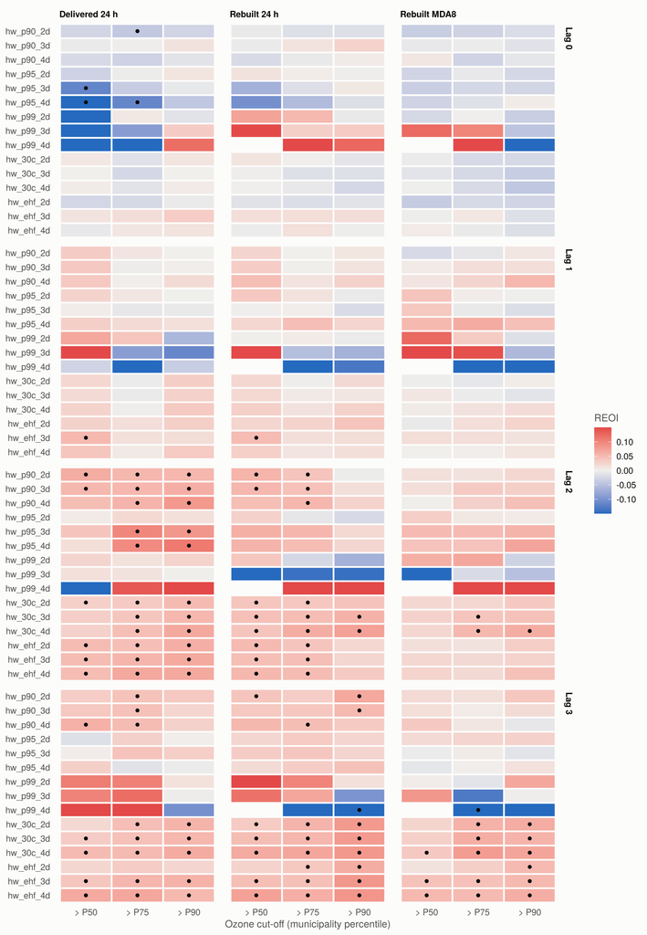

Figure 5: REOI for non-accidental mortality across heatwave definitions (rows) and ozone definitions (columns), by lag, IDW series.

```r
g <- grid[outcome == "non_accidental" & grepl("_idw_", ozone) & estimable == TRUE]
g[, series := factor(sub("_idw_gt_p[0-9]+$", "", ozone), levels = c("o3", "o3obs", "o3mda8"),
                     labels = c("Delivered 24 h", "Rebuilt 24 h", "Rebuilt MDA8"))]
g[, cutoff := paste0("> P", sub(".*_gt_p", "", ozone))]
g[, heatwave := factor(heatwave, levels = rev(unique(grid$heatwave)))]
g[, excludes_zero := low_reoi > 0 | high_reoi < 0]
limit <- 0.15
ggplot(g, aes(cutoff, heatwave, fill = estimate_reoi)) +
  geom_tile(colour = ink$surface, linewidth = 0.8) +
  geom_point(data = g[excludes_zero == TRUE], size = 1.2, colour = ink$primary) +
  facet_grid(paste("Lag", lag) ~ series) +
  scale_fill_gradient2(low = diverging[["low"]], mid = diverging[["mid"]], high = diverging[["high"]],
                       midpoint = 0, limits = c(-limit, limit), oob = scales::squish, name = "REOI") +
  labs(x = "Ozone cut-off (municipality percentile)", y = NULL) +
  theme(panel.grid.major = element_blank(), legend.position = "right",
        legend.justification = "center")
```

```r
grid_summary <- grid[estimable == TRUE, .(
  cells = .N, median_reoi = median(estimate_reoi), min_reoi = min(estimate_reoi),
  max_reoi = max(estimate_reoi), above_zero = sum(low_reoi > 0), below_zero = sum(high_reoi < 0)
), keyby = .(outcome, lag)]
grid_summary[, outcome := cause_labels[outcome]]
kable(grid_summary, digits = 3,
      col.names = c("Outcome", "Lag", "Cells", "Median REOI", "Lowest REOI", "Highest REOI",
                    "Interval above zero", "Interval below zero"))
```

Table 6: Definition grid, summary by outcome and lag: number of fitted cells, range of the REOI and cells whose 95% interval excludes zero.

| Outcome | Lag | Cells | Median REOI | Lowest REOI | Highest REOI | Interval above zero | Interval below zero |
| --- | --- | --- | --- | --- | --- | --- | --- |
| Cardiopulmonary | 0 | 266 | -0.015 | -1.205 | 0.343 | 2 | 7 |
| Cardiopulmonary | 1 | 266 | 0.001 | -10.881 | 0.498 | 12 | 7 |
| Cardiopulmonary | 2 | 266 | 0.035 | -0.604 | 0.475 | 44 | 1 |
| Cardiopulmonary | 3 | 266 | 0.041 | -4.404 | 0.652 | 55 | 2 |
| Non-accidental | 0 | 267 | -0.009 | -0.669 | 0.635 | 1 | 8 |
| Non-accidental | 1 | 267 | 0.009 | -0.791 | 0.321 | 4 | 0 |
| Non-accidental | 2 | 267 | 0.034 | -0.244 | 0.387 | 71 | 0 |
| Non-accidental | 3 | 267 | 0.036 | -1.753 | 0.482 | 97 | 3 |

With 2132 cells and no correction for multiple comparisons, about 107 intervals would exclude zero by chance alone. The full grid is in `Output/Tables/models_grid.csv`.

### 5.1 Where the positive cells are

```r
by_threshold <- grid[estimable == TRUE & outcome == "non_accidental", .(
  cells = .N, above_zero_pct = 100 * mean(low_reoi > 0), median_reoi = median(estimate_reoi)
), by = .(threshold = sub("^hw_(.*)_[0-9]d$", "\\1", heatwave), lag)]
by_threshold[, threshold := factor(threshold, levels = c("p90", "p95", "p99", "30c", "ehf"),
                                   labels = c("> P90", "> P95", "> P99", "> 30 °C", "EHF > 0"))]
kable(dcast(by_threshold, threshold ~ lag, value.var = c("above_zero_pct", "median_reoi")),
      digits = c(0, 0, 0, 0, 0, 3, 3, 3, 3),
      col.names = c("Heatwave threshold", paste("% above zero, lag", 0:3), paste("Median REOI, lag", 0:3)))
```

Table 7: Non-accidental mortality: share of grid cells (%) whose REOI interval lies above zero, by heatwave threshold and lag, with the median REOI.

| Heatwave threshold | % above zero, lag 0 | % above zero, lag 1 | % above zero, lag 2 | % above zero, lag 3 | Median REOI, lag 0 | Median REOI, lag 1 | Median REOI, lag 2 | Median REOI, lag 3 |
| --- | --- | --- | --- | --- | --- | --- | --- | --- |
| > P90 | 0 | 0 | 33 | 20 | -0.009 | 0.009 | 0.034 | 0.032 |
| > P95 | 0 | 2 | 11 | 0 | -0.017 | 0.009 | 0.036 | 0.015 |
| > P99 | 2 | 0 | 0 | 2 | -0.006 | -0.035 | 0.004 | 0.014 |
| > 30 °C | 0 | 0 | 50 | 85 | -0.010 | 0.009 | 0.039 | 0.053 |
| EHF > 0 | 0 | 6 | 37 | 72 | -0.004 | 0.016 | 0.035 | 0.047 |

## 6 Ozone as a continuous exposure

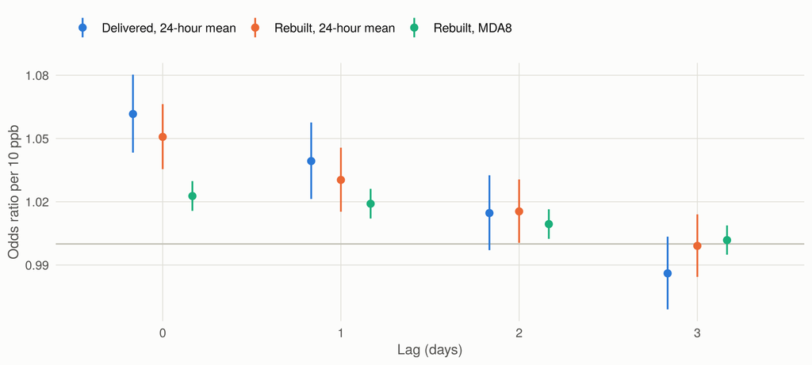

Figure 6: Odds ratio of non-accidental death per 10 ppb of ozone, by ozone series and lag, IDW, adjusted for the working heatwave indicator. Bars are 95% confidence intervals.

```r
cont <- continuous[outcome == "non_accidental" & adjustment != "none" & grepl("_idw$", series)]
cont[, series := factor(sub("_idw$", "", series), levels = c("o3", "o3obs", "o3mda8"),
                        labels = names(colour_series))]
ggplot(cont, aes(factor(lag), or, colour = series)) +
  geom_hline(yintercept = 1, colour = ink$axis) +
  geom_pointrange(aes(ymin = or_low, ymax = or_high), position = position_dodge(width = 0.5),
                  linewidth = 0.6, size = 0.35) +
  scale_colour_manual(values = colour_series) +
  labs(x = "Lag (days)", y = "Odds ratio per 10 ppb", colour = NULL)
```

```r
cont_table <- copy(continuous)[, value := ci(or, or_low, or_high, 3)]
cont_table[, outcome := cause_labels[outcome]]
kableExtra::scroll_box(
  kableExtra::kable_styling(
    kable(dcast(cont_table, outcome + series + adjustment ~ lag, value.var = "value"), format = "html",
          col.names = c("Outcome", "Ozone series", "Adjusted for", "Lag 0", "Lag 1", "Lag 2", "Lag 3")),
    bootstrap_options = c("striped", "condensed"), font_size = 12),
  height = "380px"
)
```

Table 8: Odds ratio per 10 ppb of ozone (95% confidence interval), by outcome, series, adjustment and lag.

| Outcome | Ozone series | Adjusted for | Lag 0 | Lag 1 | Lag 2 | Lag 3 |
| --- | --- | --- | --- | --- | --- | --- |
| Cardiopulmonary | o3_idw | hw_p95_2d | 1.054 (1.025 to 1.084) | 1.013 (0.985 to 1.042) | 0.998 (0.970 to 1.026) | 0.976 (0.949 to 1.004) |
| Cardiopulmonary | o3_idw | none | 1.061 (1.032 to 1.090) | 1.026 (0.998 to 1.054) | 1.003 (0.976 to 1.031) | 0.980 (0.954 to 1.008) |
| Cardiopulmonary | o3_ok | hw_p95_2d | 1.052 (1.024 to 1.081) | 1.016 (0.989 to 1.043) | 0.993 (0.967 to 1.021) | 0.974 (0.948 to 1.001) |
| Cardiopulmonary | o3_ok | none | 1.059 (1.031 to 1.087) | 1.027 (1.001 to 1.055) | 0.999 (0.973 to 1.025) | 0.979 (0.953 to 1.005) |
| Cardiopulmonary | o3mda8_idw | hw_p95_2d | 1.020 (1.008 to 1.031) | 1.011 (1.000 to 1.022) | 1.006 (0.995 to 1.017) | 1.004 (0.993 to 1.015) |
| Cardiopulmonary | o3mda8_idw | none | 1.023 (1.012 to 1.034) | 1.017 (1.006 to 1.028) | 1.008 (0.997 to 1.019) | 1.005 (0.995 to 1.016) |
| Cardiopulmonary | o3mda8_ok | hw_p95_2d | 1.022 (1.010 to 1.033) | 1.012 (1.001 to 1.024) | 1.007 (0.996 to 1.019) | 1.004 (0.993 to 1.016) |
| Cardiopulmonary | o3mda8_ok | none | 1.025 (1.014 to 1.036) | 1.018 (1.008 to 1.029) | 1.010 (0.999 to 1.021) | 1.006 (0.995 to 1.016) |
| Cardiopulmonary | o3obs_idw | hw_p95_2d | 1.048 (1.023 to 1.073) | 1.013 (0.989 to 1.037) | 1.006 (0.982 to 1.030) | 0.998 (0.974 to 1.022) |
| Cardiopulmonary | o3obs_idw | none | 1.054 (1.030 to 1.078) | 1.026 (1.003 to 1.050) | 1.011 (0.988 to 1.034) | 1.001 (0.978 to 1.024) |
| Cardiopulmonary | o3obs_ok | hw_p95_2d | 1.050 (1.025 to 1.076) | 1.019 (0.995 to 1.044) | 1.002 (0.978 to 1.026) | 0.999 (0.975 to 1.024) |
| Cardiopulmonary | o3obs_ok | none | 1.056 (1.032 to 1.081) | 1.033 (1.009 to 1.056) | 1.007 (0.984 to 1.030) | 1.003 (0.980 to 1.026) |
| Non-accidental | o3_idw | hw_p95_2d | 1.062 (1.043 to 1.080) | 1.039 (1.021 to 1.058) | 1.015 (0.997 to 1.033) | 0.986 (0.969 to 1.003) |
| Non-accidental | o3_idw | none | 1.072 (1.054 to 1.090) | 1.048 (1.031 to 1.066) | 1.020 (1.003 to 1.037) | 0.991 (0.974 to 1.008) |
| Non-accidental | o3_ok | hw_p95_2d | 1.054 (1.036 to 1.071) | 1.039 (1.022 to 1.057) | 1.012 (0.996 to 1.029) | 0.991 (0.974 to 1.008) |
| Non-accidental | o3_ok | none | 1.063 (1.046 to 1.080) | 1.047 (1.030 to 1.064) | 1.017 (1.001 to 1.034) | 0.995 (0.979 to 1.011) |
| Non-accidental | o3mda8_idw | hw_p95_2d | 1.023 (1.016 to 1.030) | 1.019 (1.012 to 1.026) | 1.009 (1.002 to 1.016) | 1.002 (0.995 to 1.009) |
| Non-accidental | o3mda8_idw | none | 1.027 (1.021 to 1.034) | 1.023 (1.016 to 1.030) | 1.012 (1.005 to 1.018) | 1.004 (0.997 to 1.010) |
| Non-accidental | o3mda8_ok | hw_p95_2d | 1.024 (1.017 to 1.032) | 1.020 (1.013 to 1.027) | 1.011 (1.004 to 1.018) | 1.003 (0.996 to 1.010) |
| Non-accidental | o3mda8_ok | none | 1.029 (1.022 to 1.036) | 1.024 (1.017 to 1.031) | 1.013 (1.007 to 1.020) | 1.005 (0.999 to 1.012) |
| Non-accidental | o3obs_idw | hw_p95_2d | 1.051 (1.035 to 1.066) | 1.030 (1.015 to 1.046) | 1.015 (1.001 to 1.031) | 0.999 (0.984 to 1.014) |
| Non-accidental | o3obs_idw | none | 1.060 (1.046 to 1.075) | 1.039 (1.025 to 1.054) | 1.021 (1.006 to 1.035) | 1.003 (0.989 to 1.018) |
| Non-accidental | o3obs_ok | hw_p95_2d | 1.053 (1.037 to 1.069) | 1.034 (1.019 to 1.050) | 1.014 (0.999 to 1.029) | 1.005 (0.990 to 1.020) |
| Non-accidental | o3obs_ok | none | 1.062 (1.048 to 1.077) | 1.043 (1.029 to 1.058) | 1.019 (1.005 to 1.034) | 1.008 (0.994 to 1.023) |

A 10 ppb step is not the same contrast in the three series: the MDA8 is about twice the 24-hour mean and varies about twice as much from day to day.

## 7 Not done yet

- Attributable mortality burden by municipality and year (needs population by age and baseline rates).
- Adjustment for PM2.5, nitrogen dioxide and humidity, and distributed lag non-linear models (deliverable 4).
- Mediation of the heatwave effect by ozone (secondary aim of the plan).
- Choice of the primary lag and of the headline definitions, which belong to the principal investigator.